# Testing for the number of interesting components in SIR

Klaus Nordhausen, Hannu Oja, David E. Tyler, Joni Virta

2026-11-16

## Sliced inverse regression

Denote the $p$-variate predictors $x_i$, $i=1,...,n$ with corresponding responses $y_i$. The predictors are assumed to follow the model
$$x_i = A s_i + b,$$
where $A$ is a non-singular $p \times p$ matrix, $b$ a $p$-vector and the random vector $s$ can be decomposed into $(s_1^T,s_2^T)^T$ with $E(s)=0$ and $Cov(s)=I_p$ where $s_1$ has dimension $k$ and $s_2$ dimension $p-k$. It is then assumed that $s_1$ is the signal part, the interesting components, which are relevant to model $y$, whereas $s_2$ is the noise part.

The working model assumption is then that
$$(y,s_1^T)^T \ is \ independent \ of \ s_2.$$
Defining $S_1=E((x-b)(x-b)^T)$ and $S_2=E(E(x-b|y)E(x-b|y)^T)$ the sliced inverse regression (SIR) can be interpreted as finding the transformation matrix $W$ such that
$$W S_1 W^T = I_p \ and \ W S_2 W^T = D,$$
where $D$ is a diagonal matrix with diagonal elements $d_1 \geq d_2 \geq ... \geq d_k > d_{k+1} = ... = d_p = 0$.

In practice $S_2$ is estimated by approximating $E(x-b|y)$ by dividing $y$ into $h$ slices where in this package $y$ is divided into $h$ intervals containing an equal number of observations.

The practical problem is to decide then the value $k$.

### Bootstrapping test a specific value of $k$

Bootstrap tests can be constructed as follows

1. Compute $\hat s_i = \hat W(x_i - \bar x_i)$, and decompose into $\hat s_{i,1}$ and $\hat s_{i,2}$.
2. Sample a bootstrap sample $(y_i^*, \hat s_{i,1}^*)$ of size $n$ from $(y_i, \hat s_{i,1})$.
3. Sample a bootstrap sample $\hat s_{i,2}^*$ of size $n$ from $\hat s_{i,2}$.
4. Compute $x_i^* = \hat W^{-1} ((\hat s_{i,1}^*)^T,(\hat s_{i,2}^*)^T)^T$.
5. Recompute the test statistic $T^*$ based on the bootstrap data $x_i^*$, $i=,1,...,n$.
6. Repeat the steps above $m$ times to obtain bootstrap test statistics $T^*_1,...,T^*_m$.

The p-value is then
$$\frac{\#(T_i^* \geq T)+1}{m+1}.$$

### Example

Some simulated data with true $k=2$:

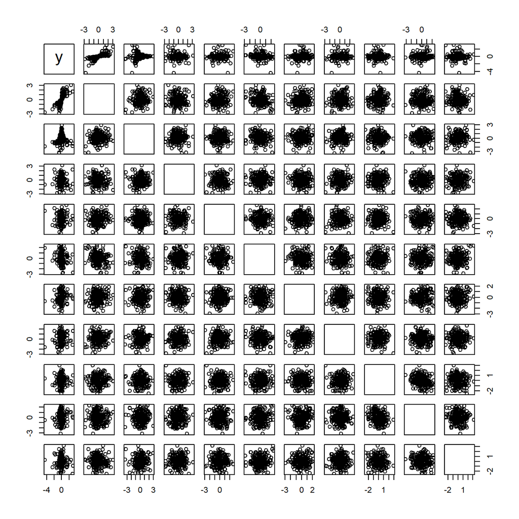

```r
set.seed(1234)
n <- 200
p <- 10
X <- matrix(rnorm(p*n), ncol = p)
eps <- rnorm(n, sd=0.25)
y <- X[, 1]/ (0.5+(X[, 2]+1.5)^2)
pairs(cbind(y,X))
```

First performing the asymptotic test

```
##
##  SIR test for subspace dimension
##
## data:  X
## T = 65.121, df = 56, p-value = 0.1891
## alternative hypothesis: the last 8 eigenvalues are not zero
```

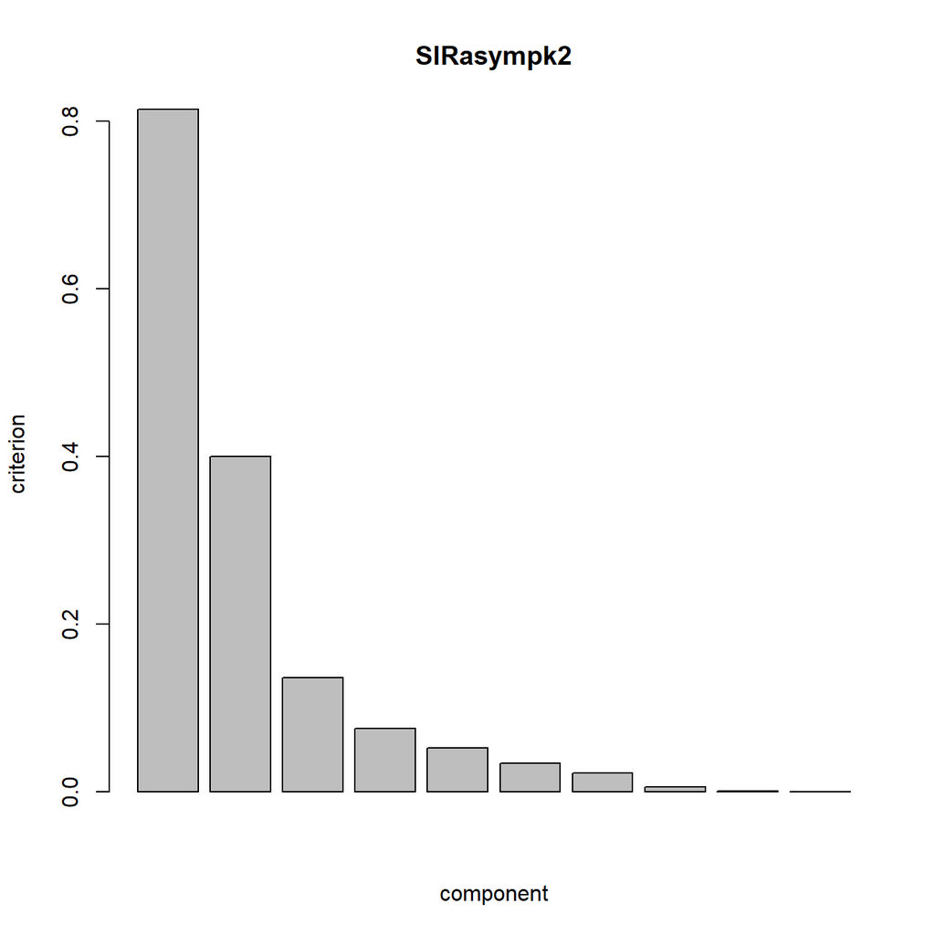

```r
library(ICtest)
SIRasympk2 <- SIRasymp(X,y,2)
screeplot(SIRasympk2)
SIRasympk2
```

Then the bootstrap test

```r
SIRbootk2 <- SIRboot(X,y,2)
SIRbootk2
```

```
##
##  SIR bootstrapping test for subspace dimension
##
## data:  X
## T = 0.32561, replications = 200, p-value = 0.209
## alternative hypothesis: the last 8 eigenvalues are not zero
```

Looking at the first two components and their relationship with the response

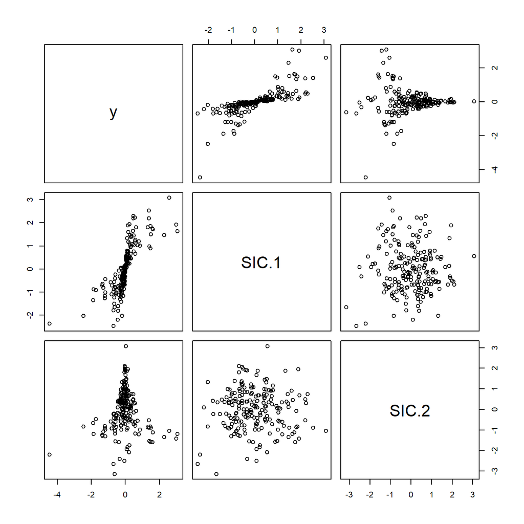

```r
pairs(cbind(y, components(SIRbootk2, which="k")))
```